# MPA and climate change: plotting

Mark Ruddy

2017-04-20

## Task summary

The project aims to look at projected climate warming in Marine Protected Areas. It uses climate models ([CMIP5](http://cmip-pcmdi.llnl.gov/cmip5/)) run for two emission scenarios (Representative Concentration Pathways - [RCPs](https://www.skepticalscience.com/rcp.php?t=1)) - 4.5degC and 8.5degC - developed as part of Intergovernmental Panel on Climate Change’s (IPCC) Fifth Assessment Report ([AR5](http://www.ipcc-data.org/sim/gcm_monthly/AR5/)).

As part of the study, the temperature data need to be modified to exclude land-based temperature measures. Additionally, adequate maps of the data need to be created.

This notebook will provide plots of SST with land surface removed (white or black) and a pleasing SST key.

## Setup

```r
# Packages
library(dplyr) # Data wrangling and exploration
library(tidyr) # Data wrangling
library(ggplot2) # Plotting
library(viridis) # Perceptually correct palettes
library(raster) # Dealing with rasters
library(rasterVis) # Plotting rasters
library(ncdf4) # Required - viewing and working with climate data in netCDF format
library(rgdal) # For working with shapefiles
library(gridExtra) # Grid arranged graphics
library(grid) # Grid arrangement
```

## Datasets

Marine Protected Areas

```r
mpas <- read.csv("../nn_extractedA2c.csv", header = TRUE)
# glimpse(mpas) # Peek at the data
```

Read CMIP5 RCP8.5 mean

```r
name85 <- "../trend_yearmean_ensemble_tos_RCP85.nc"
mean85 <- raster(name85) # Read in raster
map.extent <- c(-180, 180, -90, 90) # Reset for layer, orginal orientation was 0-360 longitude
extent(mean85) <- map.extent # Change extent
source("../revrotate.R") # Rotate raster layer to align with MPA points
mean85 <- revrotate(mean85)
extent(mean85) <- map.extent
rm("name85", "map.extent")
```

## Plotting

### Test plot temperature raster and MPAs - baseR

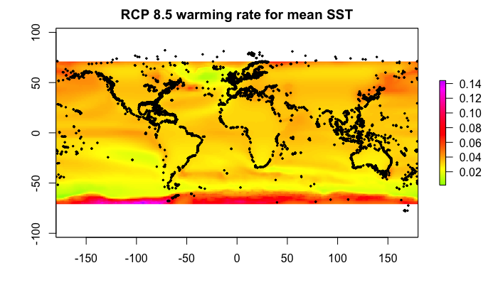

```r
plot(mean85, main = ("RCP 8.5 warming rate for mean SST"), ylim = c(-71.2, 71.2), col=rev(rainbow(200, start=.8, end=.23)))
points(mpas[,2:3], pch = 10, cex = 0.3)
```

### Test plot temperature raster and MPAs - rasterVis

[figure not shown]

```r
pts <- mpas[,2:3] # MPA points
levelplot(mean85, margin = FALSE, par.settings = viridisTheme()) +
  layer(sp.points(pts, pch = 10, cex = 0.3))
```

```r
# ERROR THROWN: 'Error using packet 1 any(sp) is not TRUE'
# Problem somehwere with plotting points as `latticeExtra::layer`
# Can't find solution at moment so will abandon using `rasterVis`
rm("pts")
```

### Test plot temperature raster and MPAs - ggplot2

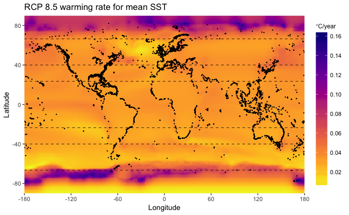

```r
# library(ggplot2) # Graphics
# library(rasterVis) # Handling netCDF
# library(viridis) # viridis colour scales for perceptually uniform palettes. See https://cran.r-project.org/web/packages/viridis/vignettes/intro-to-viridis.html
p <- gplot(mean85) + # Note: uses `gplot` here not `ggplot` - uses `rasterVis`
  geom_raster(aes(fill = value)) +
  scale_fill_viridis(direction = -1, option = "plasma", breaks = seq(0.02, 0.16, 0.02)) +
  geom_point(data = mpas, mapping = aes(x = Centroid_Longitude, y = Centroid_Latitude), size = 0.1, colour = "black") +
  guides(fill = guide_colorbar(title = expression(paste(degree, C,"/year")), barheight = 16, raster = TRUE)) +
  theme(legend.title = element_text(size = 9)) +
  ggtitle("RCP 8.5 warming rate for mean SST") +
  xlab("Longitude") +
  ylab("Latitude") +
  scale_y_continuous(breaks = seq(-80, 80, 40), expand = c(0,0)) +
  scale_x_continuous(breaks = seq(-180, 180, 60), expand = c(0,0)) +
  geom_hline(yintercept = c(-66.5, -40, -23.5, 23.5, 40, 66.5), linetype = 2, size = 0.3)
p
```

### Plot with added land surface layer

1. Obtain world land surface raster data

Read in [Natural Earth](http://www.naturalearthdata.com/) 1:110m world vector, then convert to simple raster.

```r
# Natural Earth 110m data. Comes as zip file
url <- "http://www.naturalearthdata.com/http//www.naturalearthdata.com/download/110m/physical/ne_110m_land.zip" # Land vector map web location
localDir <- "../land"
if (!file.exists(localDir)) {
  dir.create(localDir)
}
dwnld <- paste(localDir, basename(url), sep = "/") # zip file destination
if (!file.exists(dwnld)) {
  download.file(url = url, destfile = dwnld, method = "auto") # download from web
  unzip(dwnld, exdir = localDir) # unzip
}
list.files(localDir) # check unzip
```

```
[1] "ne_110m_land.dbf"         "ne_110m_land.prj"         "ne_110m_land.README.html"
[4] "ne_110m_land.shp"         "ne_110m_land.shx"         "ne_110m_land.VERSION.txt"
[7] "ne_110m_land.zip"
```

```r
# rm("url", "localDir", "dwnld") # clean up workspace
```

2. Read in land surface vector

```r
library(rgdal) # For working with shapefiles
# localDir object from chunk `get-land-vector`. Alternatively, specify location of the land vector shapefile.
land <- readOGR(dsn = localDir) # Read in shapefile using `rgdal`. No need to specify shapefile name as there's only one in the directory we created above.
land.gg <- fortify(land) # Convert shapefile to data_frame useable by ggplot. `Fortify` may be deprecated in the future and the `broom` package should be used.
str(land.gg)
```

```
'data.frame':   5143 obs. of  7 variables:
 $ long : num  -59.6 -59.9 -60.2 -62.3 -64.5 ...
 $ lat  : num  -80 -80.5 -81 -80.9 -80.9 ...
 $ order: int  1 2 3 4 5 6 7 8 9 10 ...
 $ hole : logi  FALSE FALSE FALSE FALSE FALSE FALSE ...
 $ piece: Factor w/ 2 levels "1","2": 1 1 1 1 1 1 1 1 1 1 ...
 $ id   : chr  "0" "0" "0" "0" ...
 $ group: Factor w/ 128 levels "0.1","1.1","2.1",..: 1 1 1 1 1 1 1 1 1 1 ...
```

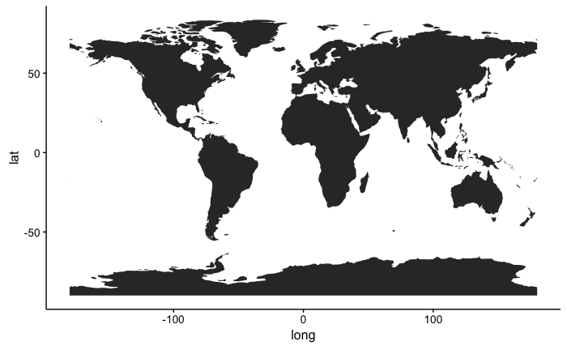

```r
# Test plot land
ggplot(data = land.gg, aes(x = long, y = lat, group = group)) + # Group is important. Tells ggplot to draw as separate not single polygons
  geom_polygon()
```

```r
rm("land")
```

3. Plot Earth polygon over temperature raster

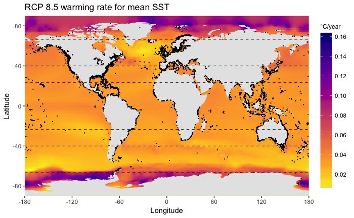

```r
p.land <- gplot(mean85) + # Note: uses `gplot` here not `ggplot` - uses `rasterVis`
  geom_raster(aes(fill = value)) +
  scale_fill_viridis(direction = -1, option = "plasma", breaks = seq(0.02, 0.16, 0.02)) +
  geom_polygon(data = land.gg, aes(x = long, y = lat, group = group), fill = "grey90") +
  geom_point(data = mpas, mapping = aes(x = Centroid_Longitude, y = Centroid_Latitude), size = 0.01, colour = "black") +
  guides(fill = guide_colorbar(title = expression(paste(degree, C,"/year")), barheight = 16, raster = TRUE)) +
  theme(legend.title = element_text(size = 9)) +
  ggtitle("RCP 8.5 warming rate for mean SST") +
  xlab("Longitude") +
  ylab("Latitude") +
  scale_y_continuous(breaks = seq(-80, 80, 40), expand = c(0,0)) +
  scale_x_continuous(breaks = seq(-180, 180, 60), expand = c(0,0)) +
  geom_hline(yintercept = c(-66.5, -40, -23.5, 23.5, 40, 66.5), linetype = 2, size = 0.3)
p.land
```

```r
rm(p.land)
```

### Plot with world map from maps::map

Try using the world map dataset the comes with R in `maps::world` instread of Natural Earth shapefile.

```r
library(maps) # Display of maps
world <- map_data(map = "world", interior = FALSE)
p.land <- gplot(mean85) + # Note: uses `gplot` here not `ggplot` - uses `rasterVis`
  geom_raster(aes(fill = value)) +
  scale_fill_viridis(direction = -1, option = "plasma", breaks = seq(0.02, 0.16, 0.02)) +
  geom_map(data = world, map = world, aes(x = long, y = lat, map_id = region), colour = "grey90", fill = "grey90") +
  geom_point(data = mpas, mapping = aes(x = Centroid_Longitude, y = Centroid_Latitude), size = 0.01, colour = "black") +
  guides(fill = guide_colorbar(title = expression(paste(degree, C,"/year")), barheight = 16, raster = TRUE)) +
  theme(legend.title = element_text(size = 9)) +
  ggtitle("RCP 8.5 warming rate for mean SST") +
  xlab("Longitude") +
  ylab("Latitude") +
  scale_y_continuous(breaks = seq(-80, 80, 40), expand = c(0,0)) +
  scale_x_continuous(breaks = seq(-180, 180, 60), expand = c(0,0)) +
  geom_hline(yintercept = c(-66.5, -40, -23.5, 23.5, 40, 66.5), linetype = 2, size = 0.3)
```

```
Ignoring unknown aesthetics: x, y
```

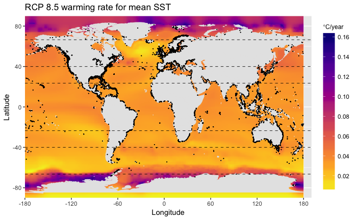

```r
p.land
```

```r
rm(p.land)
```

From comparing the two maps I think the shapefile looks better. The shapefile has been generalised to remove detail in coastlines and small island chains such as the Aleutians, which are otherwise present in `maps:world`.

### Panel plot of globe and 3 regions

Plot world.

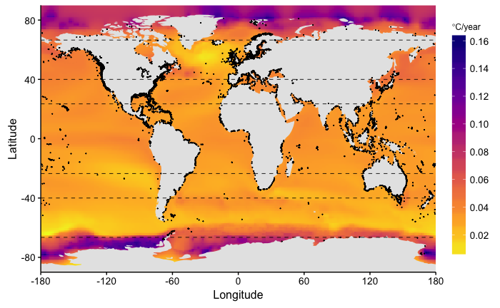

```r
p.world <- gplot(mean85) + # Note: uses `gplot` here not `ggplot` - uses `rasterVis`
  geom_raster(aes(fill = value)) +
  scale_fill_viridis(direction = -1, option = "plasma", breaks = seq(0.02, 0.16, 0.02)) +
  geom_polygon(data = land.gg, aes(x = long, y = lat, group = group), fill = "grey90") +
  geom_point(data = mpas, mapping = aes(x = Centroid_Longitude, y = Centroid_Latitude), size = 0.01, colour = "black") +
  guides(fill = guide_colorbar(title = expression(paste(degree, C,"/year")), barheight = 16, raster = TRUE)) +
  theme(legend.title = element_text(size = 9)) +
  # ggtitle("RCP 8.5 warming rate for mean SST") +
  xlab("Longitude") +
  ylab("Latitude") +
  scale_y_continuous(breaks = seq(-80, 80, 40), expand = c(0,0)) +
  scale_x_continuous(breaks = seq(-180, 180, 60), expand = c(0,0)) +
  geom_hline(yintercept = c(-66.5, -40, -23.5, 23.5, 40, 66.5), linetype = 2, size = 0.3)
p.world
```

Plot Caribbean. We’ll use `maps::world` here as it’s more detailed at larger scales than Natural Earth’s world .shp file.

```r
# Set
xlims = c(-90, -60)
ylims = c(0, 35)
world <- map_data(map = "world", interior = FALSE)
p.carib <- gplot(mean85) + # Note: uses `gplot` here not `ggplot` - uses `rasterVis`
  geom_raster(aes(fill = value)) +
  scale_fill_viridis(direction = -1, option = "plasma", breaks = seq(0.02, 0.16, 0.02)) +
  # geom_polygon(data = land.gg, aes(x = long, y = lat, group = group), fill = "grey90") +
    geom_map(data = world, map = world, aes(x = long, y = lat, map_id = region), colour = "grey90", fill = "grey90") +
  geom_point(data = mpas, mapping = aes(x = Centroid_Longitude, y = Centroid_Latitude), size = 0.01, colour = "black") +
  guides(fill = guide_colorbar(title = expression(paste(degree, C,"/year")), barheight = 16, raster = TRUE)) +
  theme(legend.title = element_text(size = 9)) +
  ggtitle("x") +
  xlab("Longitude") +
  ylab("Latitude") +
  scale_x_continuous(limits = xlims, expand = c(0, -1)) +
  scale_y_continuous(limits = ylims, expand = c(0, -1)) +
  geom_hline(yintercept = c(-66.5, -40, -23.5, 23.5, 40, 66.5), linetype = 2, size = 0.3)
```

```
Ignoring unknown aesthetics: x, y
```

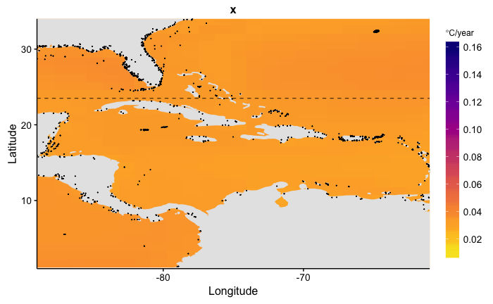

```r
p.carib
```

## Panel plot

### Test panel plot

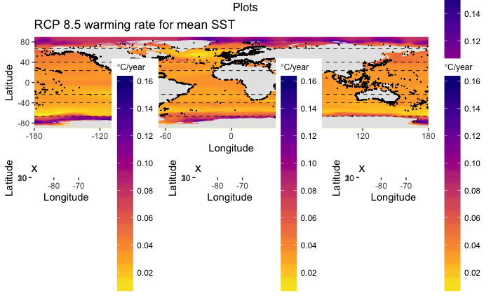

The guide_colorbar is not re-sizing within the grid. I’ll try the suggestion given [here](https://github.com/tidyverse/ggplot2/wiki/Share-a-legend-between-two-ggplot2-graphs) for producing a single legend.

### Panel plot with separate legend

Test 1

```r
# source("../functions/share_guide.R")

plots <- c("p.world", "p.world", "p.world", "p.world")
position <- c("bottom", "right")
ncol <- 1
nrow <- 2
position <- match.arg(position)

g <- ggplotGrob(plots[[1]] + theme(legend.position = position))$grobs

legend <- g[[which(sapply(g, function(x) x$name) == "guide-box")]]
lheight <- sum(legend$height)
lwidth <- sum(legend$width)

gl <- lapply(plots, function(x) x + theme(legend.position="none"))
gl <- c(gl, ncol = 1, nrow = 2)
gl <- c(c(gl[1], ncol = 1, nrow = 1), c(gl[-1], ncol = 3, nrow = 1))

arrangeGrob(do.call(arrangeGrob, gl), legend, ncol = 2, widths = unit.c(unit(1, "npc") - lwidth, lwidth))
```

Test 2

```r
source("../functions/share_guide.R")

grid_arrange_shared_guide("p.world", "p.world", "p.world", )
```

Test 3

Plot world.

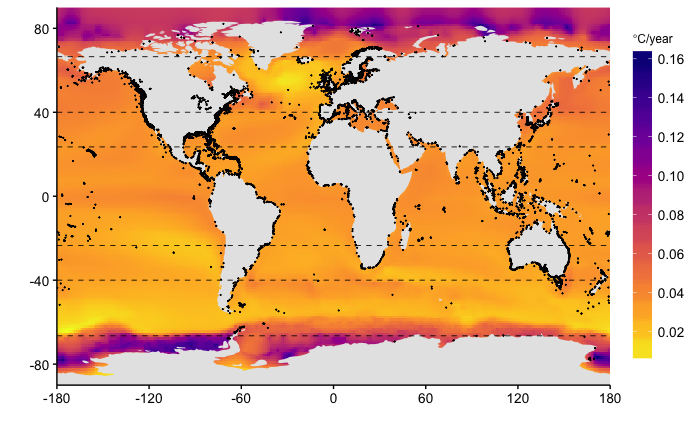

```r
ylims = c(-90, 90)
p <- gplot(mean85) + # Note: uses `gplot` here not `ggplot` - uses `rasterVis`
  geom_raster(aes(fill = value)) +
  scale_fill_viridis(direction = -1, option = "plasma", breaks = seq(0.02, 0.16, 0.02)) +
  geom_polygon(data = land.gg, aes(x = long, y = lat, group = group), fill = "grey90") +
  geom_point(data = mpas, mapping = aes(x = Centroid_Longitude, y = Centroid_Latitude), size = 0.01, colour = "black") +
  guides(fill = guide_colorbar(title = expression(paste(degree, C,"/year")), barheight = 16, raster = TRUE)) +
  theme(legend.title = element_text(size = 9)) +
  xlab("") +
  ylab("") +
  scale_y_continuous(breaks = seq(-80, 80, 40), expand = c(0,0)) +
  scale_x_continuous(breaks = seq(-180, 180, 60), expand = c(0,0)) +
  geom_hline(yintercept = c(-66.5, -40, -23.5, 23.5, 40, 66.5), linetype = 2, size = 0.3)
p
```

```r
rm(ylims)
```

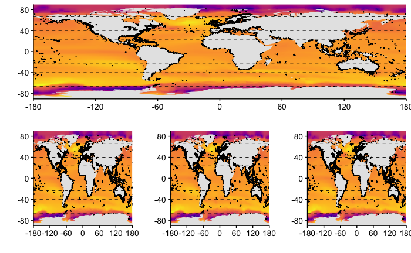

```r
library(ggplot2)
library(gridExtra)
# p <- ggplot(data.frame(x=1, y=1), aes(x,y)) + geom_point()
# g <- ggplotGrob(plots[[1]] + theme(legend.position = position))$grobs
p_l <- p + theme(legend.position="none")
g <- ggplotGrob(p + theme(legend.position = position))$grobs
grid.arrange(
  arrangeGrob(p_l, ncol = 1, widths = c(3)),
  arrangeGrob(p_l, p_l, p_l, ncol = 3, widths = rep(1,3)),
  nrow=2)
```

`gridExtra::grid.arrange` method

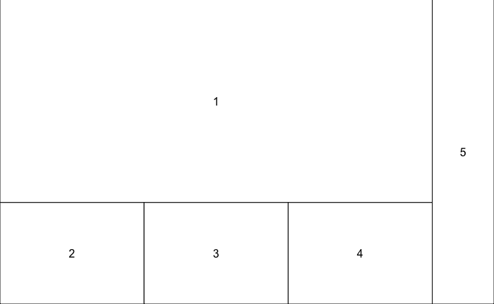

```r
gl <- lapply(1:5, function(ii) grobTree(rectGrob(),textGrob(ii)))
grid.arrange(
  arrangeGrob(gl[[1]],
              do.call(arrangeGrob, c(gl[2:4], ncol=3, list(widths=c(1,1,1)))),
          nrow=2, heights=c(2,1)), gl[[5]], nrow=1, widths=c(7,1))
```

`gridExtra::grid.arrange` gives us the arrangement we want; with 1:4 plots on the left and a single guide on the right.

Plot with ggplot grobs (graphical objects)

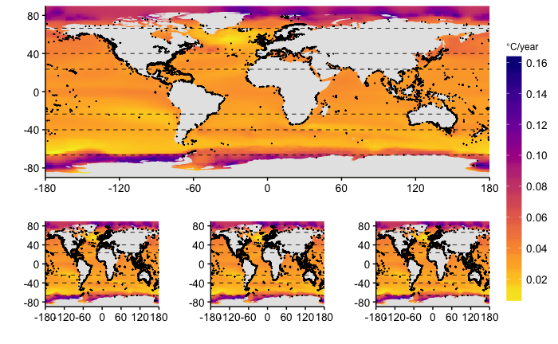

```r
p_l <- p + theme(legend.position="none") # plot p from above
g <- ggplotGrob(p + theme(legend.position = "right"))$grobs
legend <- g[[which(sapply(g, function(x) x$name) == "guide-box")]]
mp <- grid.arrange(
  arrangeGrob(p_l,
              do.call(arrangeGrob, c(list(p_l, p_l, p_l), ncol=3, list(widths=c(1,1,1)))),
          nrow=2, heights=c(5,3)), legend, nrow=1, widths=c(8,1))
```

```r
ggsave(filename = "multi-plot", plot = mp, path = "../images/", device = "pdf", units = "in", width = 10, height = 8)
```

Only need to crop the shape file as `ggplot2` tries to join up the wrong polygon vertices in plots that merely limit axes.

```r
# Crop raster and world land shapefile for better use of whole map space in plot.
# Using `raster::extract`
## Limits
crop.e <- extent(c(-180, 180, -82, 84)) # Crop at 80 deg latitude

## Raster
crop.r <- crop(cmip.sst, crop.e)

## World land
localDir <- "../land"
land <- readOGR(dsn = localDir) # Read in shapefile using `rgdal`. No need to specify shapefile name as there's only one in the directory we created above. Creates a 'SpatialPolygonsDataFrame'
land.gg <- fortify(land)

crop.l <- crop(land, crop.e)

crop.l.gg <- fortify(crop.l)

## MPAs
mpas.xy <- read.csv("../nn_extractedA2c.csv", header = TRUE)
```

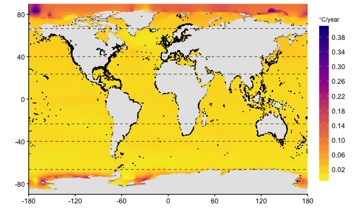

```r
p.wc <- gplot(cmip.sst) + # Note: uses `gplot` here not `ggplot` - uses `rasterVis`
  geom_raster(aes(fill = value)) +
  scale_fill_viridis(direction = -1, option = "plasma", breaks = seq(0.02, 0.40, 0.04)) +
  geom_polygon(data = land.gg, aes(x = long, y = lat, group = group), fill = "grey90") +
  geom_point(data = mpas.xy, mapping = aes(x = Centroid_Longitude, y = Centroid_Latitude), size = 0.01, colour = "black") +
  guides(fill = guide_colorbar(title = expression(paste(degree, C,"/year")), barheight = 16, raster = TRUE)) +
  theme(legend.title = element_text(size = 9)) +
  xlab("") +
  ylab("") +
  scale_y_continuous(breaks = seq(-80, 80, 40), expand = c(0,0)) +
  scale_x_continuous(breaks = seq(-180, 180, 60), expand = c(0,0)) +
  geom_hline(yintercept = c(-66.5, -40, -23.5, 23.5, 40, 66.5), linetype = 2, size = 0.3)
p.wc
```